# Broad Ctype Normalisation

Alberto Perez-Posada @apposada

2/28/2023

## Loading Necessary Packages

```r
library(vroom)
library(reshape2)
library(ComplexHeatmap)
library(circlize)
library(viridis)
library(colorspace)
library(RColorBrewer)
library(dplyr)
library(stringr)
library(ggplot2)
library(gplots)
library(data.table)
library(DESeq2)
```

## Data Load

First we will load a table containing information of the different cell types to inform on cluster identity, annotate the plots with colors, etc.

```r
plei_ctypes <- read.delim2(
  "./data/01_celltypedata/plei_ctypes.tsv",
  header = T
)

#table cluster name - color, for annotating purposes
plei_ctypes_broad_col <- unique(data.frame(
  broad = plei_ctypes$Broad_Type,
  col = plei_ctypes$Colour_group
))

head(plei_ctypes[,1:5])
```

```
##   Cluster      Names_leiden_1.5       Name_marker     Broad_Type Colours
## 1       1      piwi_pos_cells_1                   piwi_pos_cells #585858
## 2       2      piwi_pos_cells_2                   piwi_pos_cells #9D9D9D
## 3       8    nidogen1_pos_cells PrileiEVm002280t1 piwi_pos_cells #B5B5B5
## 4      18 epidermal_progenitors                        epidermis #6BAED6
## 5       0           epidermis_1                        epidermis #75CFEA
## 6      11           epidermis_2                        epidermis #93C5FB
```

We begin our with a matrix of transcript counts summed at the pseudo-bulk level of BROAD cell types.

```r
plei_counts_broad_all <- vroom(
  "./data/02_geneexpression/Pristina_atlas_counts_broad.tsv",
  col_names=T
)
```

```
## ──────────────────────────────────────────────────────── Delimiter: "\t" chr
## (1): ...1 dbl (18): arginase+ cells, carbohydrate metabolic cells, chaetal
## sacs, eleoc...
```

```r
plei_counts_broad_all[,2:19] <- plei_counts_broad_all[,2:19]

plei_counts_broad <- as.data.frame(plei_counts_broad_all)

rownames(plei_counts_broad) <- plei_counts_broad_all$...1
plei_counts_broad$...1 <- NULL # remove gene names column

colnames(plei_counts_broad) <- gsub(" ","_",gsub("\\+","_pos",colnames(plei_counts_broad)))

head(plei_counts_broad[,1:5])
```

```
##                   arginase_pos_cells carbohydrate_metabolic_cells chaetal_sacs
## PrileiEVm000001t1                  3                            2           18
## PrileiEVm000002t1                 25                           52           94
## PrileiEVm000003t1                  2                            1            6
## PrileiEVm000004t1                  0                            1            7
## PrileiEVm000005t1                  2                            5            5
## PrileiEVm000006t1                  3                            3            7
##                   eleocytes epidermis
## PrileiEVm000001t1        17       116
## PrileiEVm000002t1      3236       525
## PrileiEVm000003t1        24        88
## PrileiEVm000004t1         8       975
## PrileiEVm000005t1         7        29
## PrileiEVm000006t1         7        46
```

We will rearrange the celltype/color table to match the column order of the counts table (for easier plotting down below)

```r
plei_ctypes_broad_col <- plei_ctypes_broad_col[match(colnames(plei_counts_broad),plei_ctypes_broad_col$broad),]
```

And we add a low, arbitrary threshold to remove the sparse genes that have less than 50 counts across all clusters.

```r
plei_counts_broad <- plei_counts_broad[rowSums(plei_counts_broad) > 50,] # post-hoc estimated with the plot of hvg
head(plei_counts_broad[,1:5])
```

```
##                   arginase_pos_cells carbohydrate_metabolic_cells chaetal_sacs
## PrileiEVm000001t1                  3                            2           18
## PrileiEVm000002t1                 25                           52           94
## PrileiEVm000003t1                  2                            1            6
## PrileiEVm000004t1                  0                            1            7
## PrileiEVm000005t1                  2                            5            5
## PrileiEVm000006t1                  3                            3            7
##                   eleocytes epidermis
## PrileiEVm000001t1        17       116
## PrileiEVm000002t1      3236       525
## PrileiEVm000003t1        24        88
## PrileiEVm000004t1         8       975
## PrileiEVm000005t1         7        29
## PrileiEVm000006t1         7        46
```

## Normalisation by library size

There are clusters with massively different sizes (i.e. clusters of thousands of cells vs clusters of hundreds).

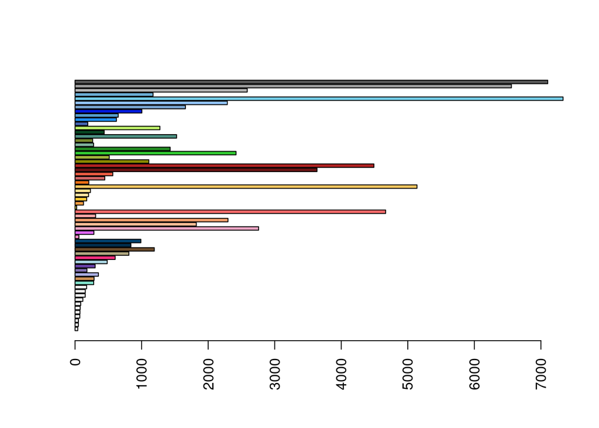

And if we check the distribution of counts per cluster:

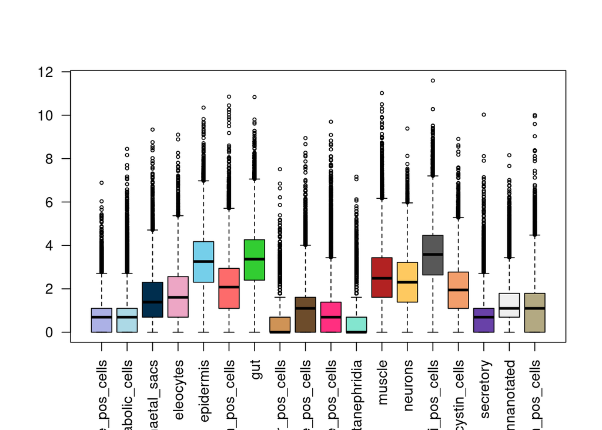

Since we are treating each cluster as a separate “condition”, one can expand this to consider them as separate RNA libraries. Thus we can apply normalisation methods by library composition such as DESeq2.

```r
plei_dds_broad <- DESeqDataSetFromMatrix(countData = plei_counts_broad,
                                   colData = data.frame(condition = colnames(plei_counts_broad)),
                                   design = ~ condition)
plei_dds_broad <- estimateSizeFactors(plei_dds_broad)
plei_counts_broad_norm <- counts(plei_dds_broad, normalized=TRUE)

head(plei_counts_broad_norm[,1:5])
```

```
##                   arginase_pos_cells carbohydrate_metabolic_cells chaetal_sacs
## PrileiEVm000001t1          13.861304                     7.049649    16.541600
## PrileiEVm000002t1         115.510865                   183.290871    86.383913
## PrileiEVm000003t1           9.240869                     3.524824     5.513867
## PrileiEVm000004t1           0.000000                     3.524824     6.432845
## PrileiEVm000005t1           9.240869                    17.624122     4.594889
## PrileiEVm000006t1          13.861304                    10.574473     6.432845
##                     eleocytes  epidermis
## PrileiEVm000001t1   12.819101  16.475895
## PrileiEVm000002t1 2440.153621  74.567629
## PrileiEVm000003t1   18.097555  12.498955
## PrileiEVm000004t1    6.032518 138.482740
## PrileiEVm000005t1    5.278453   4.118974
## PrileiEVm000006t1    5.278453   6.533545
```

Here below are plots of the expression of the first 200 genes in two different clusters, before and after normalisation. We can observe how these genes “behave” similarly before and after normalisation, but the range of variation is much more similar between clusters regardless of their size in cells.

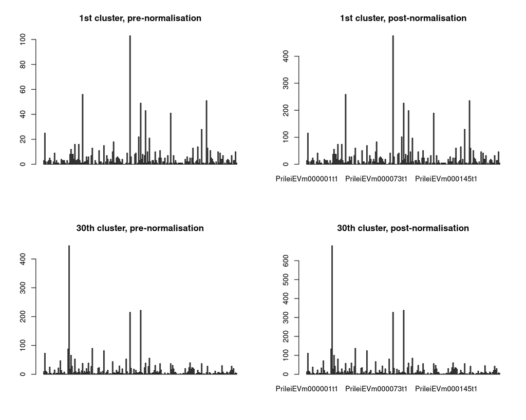

A birds-eye view of this across all clusters:

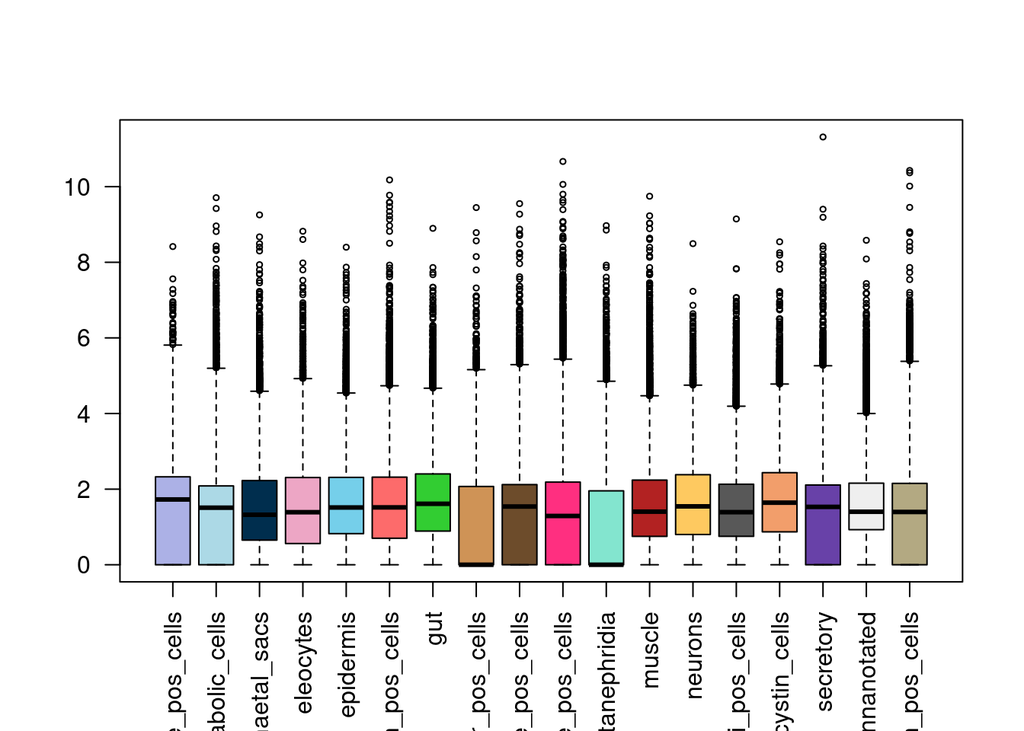

This method is not perfect but it is accurate enough for our purpose.

## Counts-per-million normalisation

We normalise the DESeq2-normalised (pseudo)counts as counts-per-million (CPM)

```r
plei_cpm_broad <- apply(
  plei_counts_broad_norm,
  2,
  function(x) {x * 1e6 / sum (x)}
)
rownames(plei_cpm_broad) <- rownames(plei_counts_broad_norm)
plei_cpm_broad <- as.data.frame(plei_cpm_broad)
```

Visual comprobation:

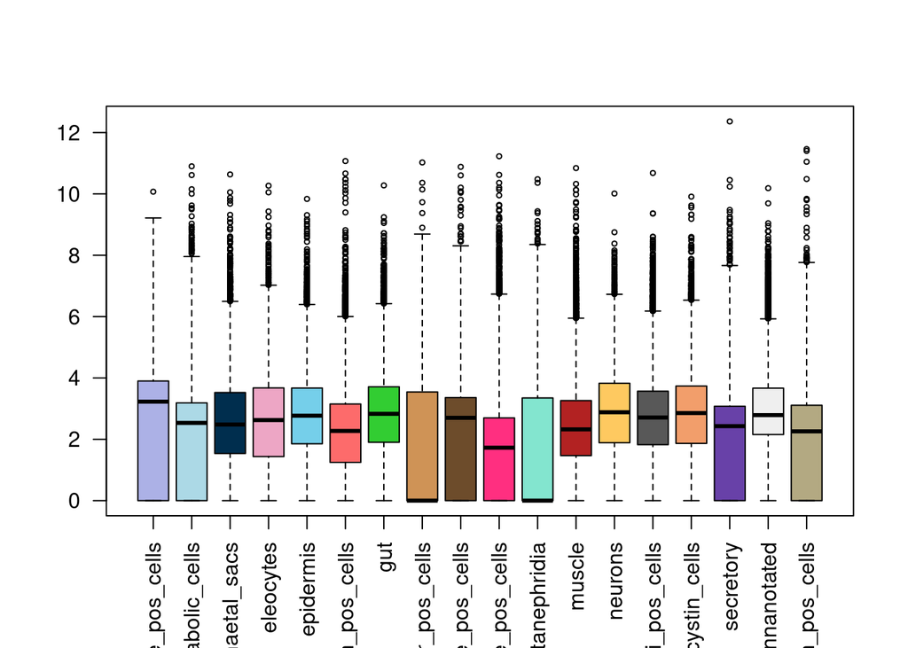

Is there any column that was not normalised to CPM?

```r
colSums(plei_cpm_broad)
```

```
##           arginase_pos_cells carbohydrate_metabolic_cells
##                      1000000                      1000000
##                 chaetal_sacs                    eleocytes
##                      1000000                      1000000
##                    epidermis             globin_pos_cells
##                      1000000                      1000000
##                          gut              ldlrr_pos_cells
##                      1000000                      1000000
##       lipoxygenase_pos_cells       lumbrokinase_pos_cells
##                      1000000                      1000000
##                metanephridia                       muscle
##                      1000000                      1000000
##                      neurons               piwi_pos_cells
##                      1000000                      1000000
##             polycystin_cells                    secretory
##                      1000000                      1000000
##                  unnanotated            vigilin_pos_cells
##                      1000000                      1000000
```

We finally write the tables:

```r
write.table(
  plei_counts_broad_norm,
  file = "./outputs/plei_counts_broad_norm.tsv",
  sep = "\t",
  dec = ".",
  row.names = TRUE,
  quote = FALSE
)

write.table(
  plei_cpm_broad,
  file = "./outputs/plei_counts_broad_norm_cpm.tsv",
  sep = "\t",
  dec = ".",
  row.names = TRUE,
  quote = FALSE
)
```